# Offleaks

This project for Social and Economic Networks course uses Offshore Leaks Database found here https://offshoreleaks.icij.org/.

## Yearly counts development

One would like to know how many accounts have been opened throughout years.

The sample size for answering this question is 309736.

The earliest opened account belongs to 1918 and the latest comes from the future 2020.

The most fruitful years for the offshore accounts are the following:

```
## Source: local data frame [6 x 2]
##
##   incorporation_year     n
##                (dbl) (int)
## 1               2007 26774
## 2               2006 24924
## 3               2005 22454
## 4               2004 20109
## 5               2008 17342
## 6               2000 16327
```

Overall, that is how the process looks like:

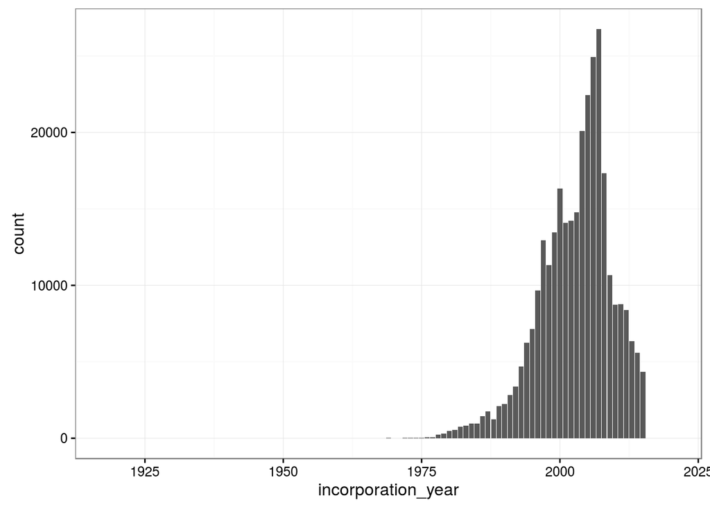

## CEE countries counts

Number of firms related to different Central-Eastern European countries.

```
##
##        Hungary         Poland        Romania        Croatia       Slovenia
##             90            161              8             19             21
##         Serbia Czech Republic        Ukraine        Belarus      Lithuania
##              9            172            465             34             33
##         Latvia        Estonia
##           2938            881
```

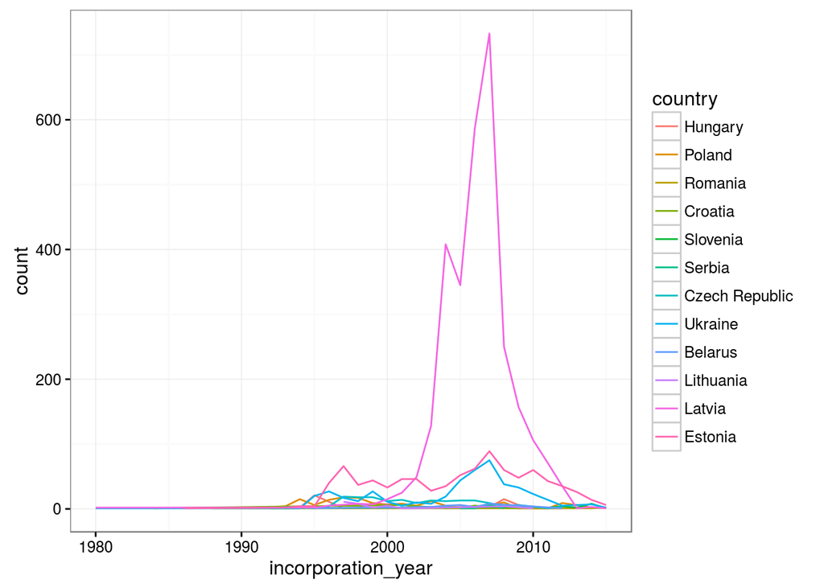

Without Latvia:

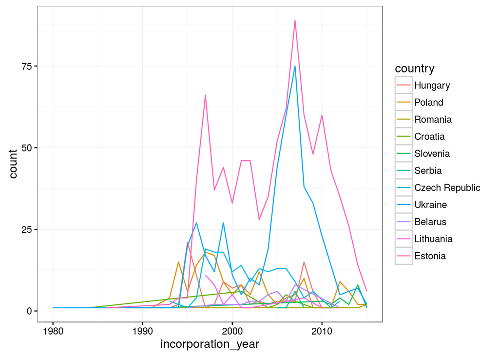

## CEE countries relationships

It is interesting to see how are the relationships built around the entities from these countries.

There are 13188 known links related to CEE countries entities.

The count allocation of the nodes from origin to end is the following:

```
##                 end
## origin           address cee-entity non-cee-entity
##   cee-entity        1948          2              7
##   intermediary         0       4831              0
##   non-cee-entity       0          6              0
##   officer              0       6394              0
```

### “registered address” relationship type

When the origin node is a cee-entity, it points to either addresses or other entities.

When it is a cee-entity connecting to an address, the relationship type of the nodes are registered address. Do the countries of the cee-entity correspond to the address specified?

The mean of matches of the cee-entity and the address countries is:

```
## [1] 1
```

Then these links of type `"cee-entity"-"registered address"-"address"` present no interest for the further study.

### “same name and registration date as” relationship type

Now the amount of links is reduced to 11240.

There are some entites linked to other entites through same name and registration date as.

```
##                 origin   node_1                           rel_type
## 1264595 non-cee-entity 10013420 same name and registration date as
## 1265366 non-cee-entity 10051831 same name and registration date as
## 1265407     cee-entity 10052709 same name and registration date as
## 1266042 non-cee-entity 10129355 same name and registration date as
## 1267412     cee-entity   189353 same name and registration date as
## 1267413     cee-entity   189354 same name and registration date as
## 1267466     cee-entity   197215 same name and registration date as
## 1267472 non-cee-entity   194227 same name and registration date as
## 1267508     cee-entity   208045 same name and registration date as
## 1267509 non-cee-entity   208083 same name and registration date as
## 1267521 non-cee-entity   232413 same name and registration date as
## 1267536     cee-entity   232019 same name and registration date as
## 1267571     cee-entity   193494 same name and registration date as
## 1267573     cee-entity   194308 same name and registration date as
```

[output cut: 17 more lines]

The assumed way to deal with duplicates in this case is to bring in the edges connected to the found non-cee-entites and replace all instances of `node_2` as `node_1`.

The treatment leads to 11272 distinct link observations.

Now the relationships between the nodes related to CEE countries are as follows:

```
##                      origin
## relationship          intermediary officer
##   beneficial owner of            0       7
##   beneficiary of                 0     200
##   director of                    0    2505
##   intermediary of             4843       0
##   secretary of                   0      19
##   shareholder of                 0    3698
```

## Constructing the network

It is possible now to construct the network.

So far by construction the network is bipartite: TRUE.

Below is the first attempt to plot the resulting network.

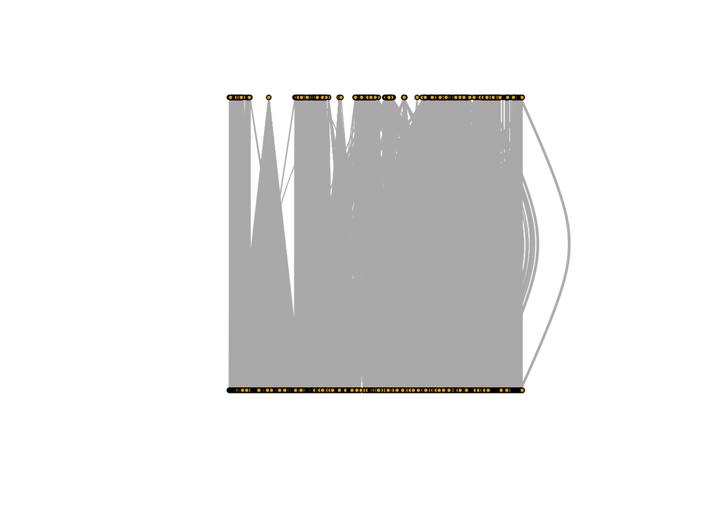

## Nodes decomposed

The main connections file provides 1269796 links/edges. At both ends one can find different players.

### Origin nodes

There are 462468 unique origin nodes/vertices.

They are distributed among the types in the following manner:

| Entities | Addresses | Intermediaries | Officers |
| --- | --- | --- | --- |
| 93572 | 960 | 23600 | 345475 |
| 20.1834744% | 0.2070719% | 5.0905185% | 74.5189352% |

A note. The decomposition does not sum up to the number of unique entries. 463607 = 462468 is FALSE.

### Receiving nodes

Looking at the unique receiving nodes/vertices, one can find that there are 492143 of them.

They are distributed among the types in the following manner:

| Entities | Addresses | Intermediaries | Officers |
| --- | --- | --- | --- |
| 319122 | 151043 | 355 | 21664 |
| 64.8379468% | 30.6883198% | 0.0721275% | 4.4016059% |

In the same manner 492184 = 492143 is FALSE.

### Origins and ends overall

The cross tabulated origins and ends from all the edges available are presented in the table below.

```
##
##                address entity intermediary officer
##   address          960      0            0       0
##   entity         93623   3768            0       0
##   intermediary    9358 362425           21      56
##   officer       213491 538166          349   47579
```

### Visualizing

At the very first place, the nodes are very intertwined.

For example, there are 1139 officers listed as intermediaries and vise versa. They are separated into a new group labeled “o+i”.

It is possible to identify, through which relationship the types of nodes are related.

It is performed through network formation of the initial information on the edges. The node size is proportional to the amount of registered nodes of the type. The links’ width represents the amount of connections between the nodes.

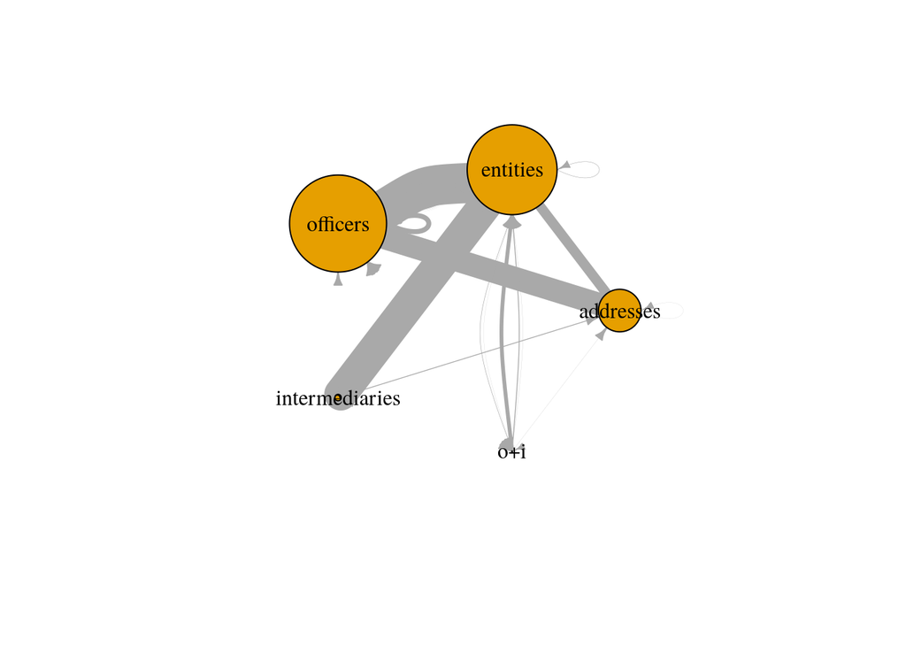

There is some coherent merging of the information required.

```
##     from  to                                         type quantity
## 1      a   a                              same address as      960
## 2      e   e                               related entity      622
## 3      e   e           same name and registration date as     3146
## 4      e   a                           registered address    93623
## 5      o   a                           registered address   213491
## 6      o   e                        alternate director of      409
## 7      o   e                                 appointor of       32
## 8      o   e                       assistant secretary of      574
## 9      o   e                                   auditor of      202
## 10     o   e             authorised person / signatory of     1176
## 11     o   e                      authorized signatory of        1
## 12     o   e                      auth. representative of       32
## 13     o   e                            bank signatory of      123
## 14     o   e                          beneficial owner of     1797
```

[output cut: 105 more lines]